# HSC Survey Results

# German Bank Survey # 5 Results from 27/09/2025

## Survey Details

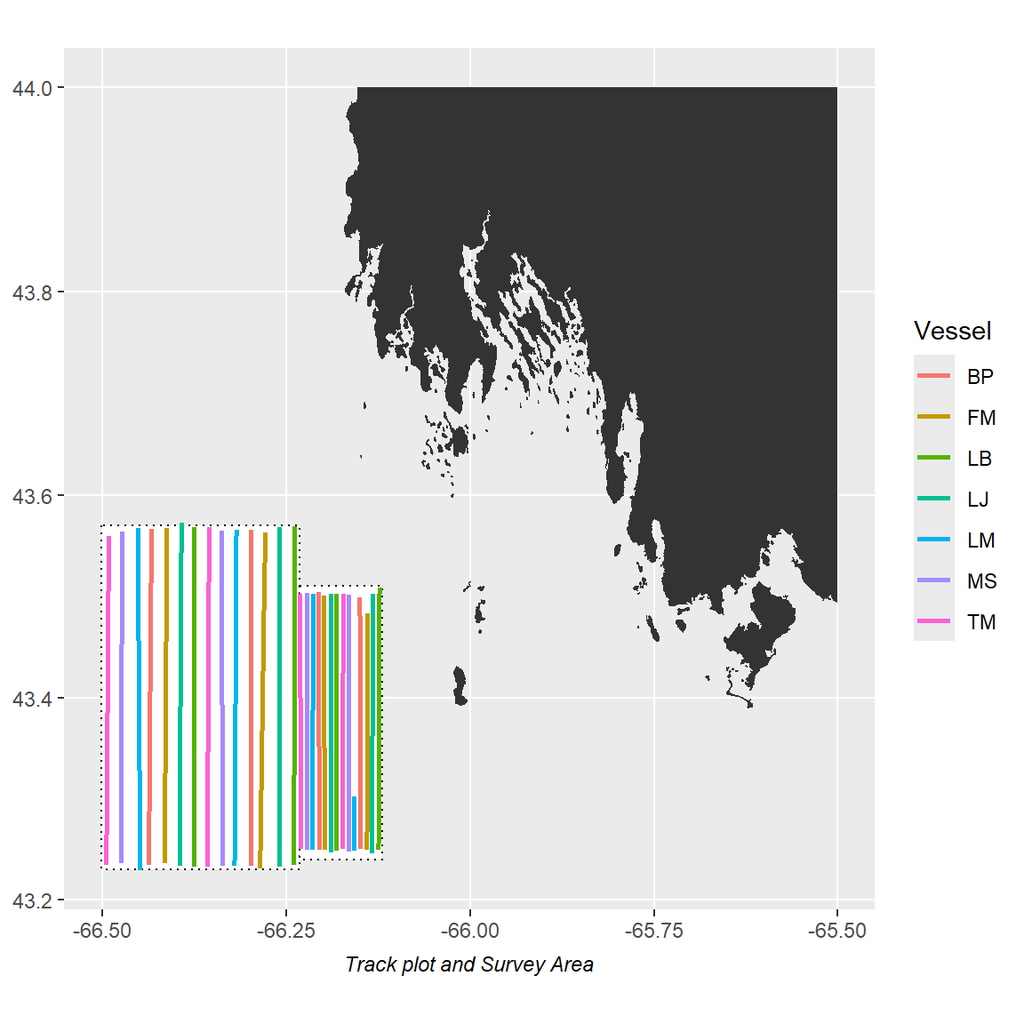

All vessels ran two transects in the German Bank box and two transect in the Seal Island Box.

There was no plankton tow or CTD cast conducted.

No tags were applied during this survey.

Samples were obtained for target strength estimation.

### Acoustic Equipment

Each vessel was equipped with a Simrad ES38-18/200-18C combi (2-in-1) transducer prior to the survey that contains a 38kHz split beam and 200 kHz single beam transducer. Data was logged to the computer hard-drive for post-processing. All participating boats were calibrated on 38kHz before the survey.

## Survey Results

### Main Results

The results are subject to change as DFO will re-evaluate data editing, area estimation and apply a target strength.

**Preliminary biomass prediction for German Bank using standardized parallel transects is 6,754mt, and with turnover applied 2,138mt. The preliminary biomass estimate for Seal Island is 5,048mt.**

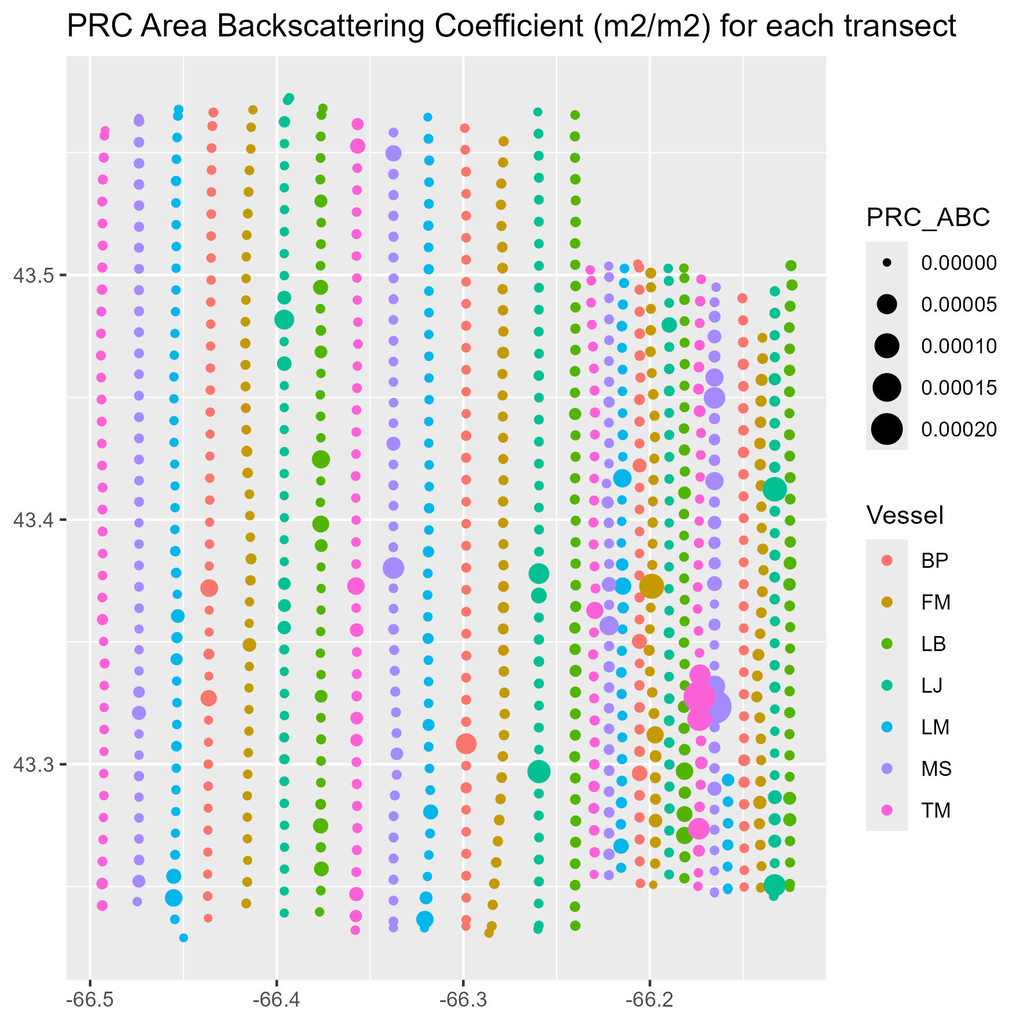

### Transect Details

Table 1: Transect Details

| Vessel | Transect # | Date/Time Start | Date/Time End | Start Lon | Start Lat | End Lon | End Lat | Location | Distance (km) | Speed |
| --- | --- | --- | --- | --- | --- | --- | --- | --- | --- | --- |
| BP | T03 | 2025-09-28 00:25:59 | 2025-09-28 02:48:55 | -66.299 | 43.566 | -66.299 | 43.234 | GB | 36.94 | 8.37 |
| BP | T04 | 2025-09-28 03:22:35 | 2025-09-28 05:44:01 | -66.438 | 43.234 | -66.434 | 43.566 | GB | 36.94 | 8.46 |
| BP | T01 | 2025-09-27 20:17:49 | 2025-09-27 21:58:00 | -66.150 | 43.499 | -66.150 | 43.250 | GB | 27.74 | 8.97 |
| BP | T02 | 2025-09-27 22:14:16 | 2025-09-27 23:56:36 | -66.206 | 43.249 | -66.206 | 43.504 | GB | 28.45 | 9.01 |
| FM | T03 | 2025-09-28 01:34:24 | 2025-09-28 03:59:48 | -66.279 | 43.563 | -66.286 | 43.231 | GB | 38.33 | 8.54 |
| FM | T04 | 2025-09-28 04:32:21 | 2025-09-28 06:55:04 | -66.416 | 43.236 | -66.413 | 43.567 | GB | 37.61 | 8.54 |
| FM | T01 | 2025-09-27 21:09:59 | 2025-09-27 22:58:12 | -66.140 | 43.483 | -66.141 | 43.249 | GB | 27.03 | 8.09 |
| FM | T02 | 2025-09-27 23:13:31 | 2025-09-28 01:03:17 | -66.198 | 43.249 | -66.200 | 43.501 | GB | 28.81 | 8.50 |
| LB | T03 | 2025-09-28 00:15:04 | 2025-09-28 02:44:05 | -66.239 | 43.569 | -66.240 | 43.234 | GB | 38.34 | 8.34 |
| LB | T04 | 2025-09-28 03:20:40 | 2025-09-28 05:42:00 | -66.376 | 43.233 | -66.375 | 43.568 | GB | 38.10 | 8.73 |
| LB | T01 | 2025-09-27 19:45:25 | 2025-09-27 21:39:48 | -66.124 | 43.509 | -66.125 | 43.250 | GB | 29.80 | 8.44 |
| LB | T02 | 2025-09-27 21:59:10 | 2025-09-27 23:46:38 | -66.182 | 43.249 | -66.182 | 43.503 | GB | 29.03 | 8.75 |
| LJ | T03 | 2025-09-28 00:43:33 | 2025-09-28 03:03:12 | -66.259 | 43.568 | -66.260 | 43.233 | GB | 37.34 | 8.66 |
| LJ | T04 | 2025-09-28 03:36:47 | 2025-09-28 06:01:13 | -66.396 | 43.233 | -66.393 | 43.572 | GB | 37.80 | 8.48 |
| LJ | T01 | 2025-09-27 20:25:13 | 2025-09-27 22:14:22 | -66.133 | 43.502 | -66.134 | 43.246 | GB | 28.50 | 8.46 |
| LJ | T02 | 2025-09-27 22:29:33 | 2025-09-28 00:16:53 | -66.189 | 43.247 | -66.190 | 43.503 | GB | 28.47 | 8.59 |
| LM | T03 | 2025-09-28 00:58:55 | 2025-09-28 03:13:44 | -66.318 | 43.566 | -66.321 | 43.233 | GB | 37.55 | 9.02 |
| LM | T04 | 2025-09-28 03:45:11 | 2025-09-28 06:05:38 | -66.449 | 43.229 | -66.453 | 43.568 | GB | 38.38 | 8.85 |
| LM | T01 | 2025-09-27 22:04:51 | 2025-09-27 22:26:38 | -66.158 | 43.302 | -66.158 | 43.249 | GB | 6.06 | 9.02 |
| LM | T02 | 2025-09-27 22:42:28 | 2025-09-28 00:27:01 | -66.215 | 43.249 | -66.214 | 43.503 | GB | 28.64 | 8.87 |
| MS | T03 | 2025-09-28 00:31:55 | 2025-09-28 02:56:08 | -66.338 | 43.565 | -66.337 | 43.233 | GB | 39.11 | 8.79 |
| MS | T04 | 2025-09-28 03:38:24 | 2025-09-28 05:56:07 | -66.476 | 43.236 | -66.474 | 43.564 | GB | 38.07 | 8.96 |
| MS | T01 | 2025-09-27 19:34:13 | 2025-09-27 21:48:30 | -66.165 | 43.502 | -66.165 | 43.247 | GB | 31.05 | 7.49 |
| MS | T02 | 2025-09-27 22:07:44 | 2025-09-27 23:50:57 | -66.223 | 43.249 | -66.222 | 43.504 | GB | 30.19 | 9.48 |
| TM | T03 | 2025-09-28 01:27:18 | 2025-09-28 03:53:52 | -66.356 | 43.568 | -66.358 | 43.232 | GB | 37.35 | 8.26 |
| TM | T04 | 2025-09-28 04:32:03 | 2025-09-28 06:50:25 | -66.495 | 43.235 | -66.492 | 43.559 | GB | 36.11 | 8.45 |
| TM | T01 | 2025-09-27 20:46:31 | 2025-09-27 22:46:31 | -66.173 | 43.503 | -66.174 | 43.250 | GB | 28.12 | 7.59 |
| TM | T02 | 2025-09-27 23:03:31 | 2025-09-28 00:47:27 | -66.230 | 43.251 | -66.232 | 43.502 | GB | 28.00 | 8.73 |

### Survey Summary

Table 2: Acoustic Survey Results

| Vessel | Transect No. | Target Strength (db/kg) | Mean Sa (/m2) | Biomass Density (kg/m2) |
| --- | --- | --- | --- | --- |
| MS | T01 | -35.5 | -48.033 | 0.056 |
| TM | T01 | -35.5 | -48.597 | 0.049 |
| LJ | T01 | -35.5 | -51.026 | 0.028 |
| FM | T02 | -35.5 | -52.120 | 0.022 |
| LJ | T03 | -35.5 | -53.209 | 0.017 |
| LB | T02 | -35.5 | -53.549 | 0.016 |
| LB | T04 | -35.5 | -53.946 | 0.014 |
| LM | T02 | -35.5 | -54.065 | 0.014 |
| MS | T03 | -35.5 | -54.678 | 0.012 |
| MS | T02 | -35.5 | -54.899 | 0.011 |
| TM | T03 | -35.5 | -55.333 | 0.010 |
| LJ | T04 | -35.5 | -55.417 | 0.010 |
| BP | T02 | -35.5 | -55.951 | 0.009 |
| LB | T01 | -35.5 | -55.971 | 0.009 |
| FM | T01 | -35.5 | -56.332 | 0.008 |
| LM | T01 | -35.5 | -56.669 | 0.008 |
| BP | T03 | -35.5 | -56.702 | 0.008 |
| LM | T03 | -35.5 | -56.792 | 0.007 |
| LM | T04 | -35.5 | -57.006 | 0.007 |
| TM | T02 | -35.5 | -57.118 | 0.007 |
| BP | T04 | -35.5 | -57.333 | 0.007 |
| LB | T03 | -35.5 | -57.541 | 0.006 |
| LJ | T02 | -35.5 | -58.240 | 0.005 |
| FM | T03 | -35.5 | -58.399 | 0.005 |
| BP | T01 | -35.5 | -58.985 | 0.004 |
| MS | T04 | -35.5 | -58.996 | 0.004 |
| FM | T04 | -35.5 | -60.585 | 0.003 |
| TM | T04 | -35.5 | -61.181 | 0.003 |

Note:  
Transects are listed from greatest to least backscatter.

Table 3: Survey Summary Table

| Layer | Target Strength | Area (km2) | Mean Sa | Density (kg/m2) | Biomass (tons) | Percent Area | Percent Biomass | Standard Error (tons) | Standard Error (%) |
| --- | --- | --- | --- | --- | --- | --- | --- | --- | --- |
| German Bank | -35.5 | 826 | -56.3742 | 0.0082 | 6,753.911 | NA | NA | 920.24 | 13.63 |
| Seal Island | -35.5 | 274 | -52.8459 | 0.0176 | 5,048.458 | NA | NA | 1,184.23 | 23.46 |
| School Survey | NA | NA | NA | NA | NA | NA | NA | NA | NA |

### Greatest Biomass Densities

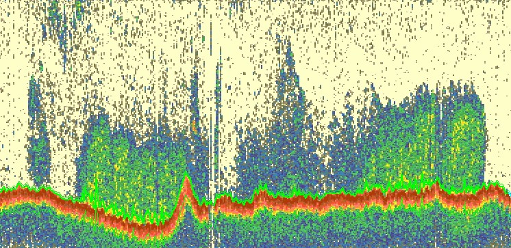

A snip from the transect with the greatest biomass density (kg/m2)

The single point with the largest biomass density (kg/m2) was recorded by **MS**, at the following location:

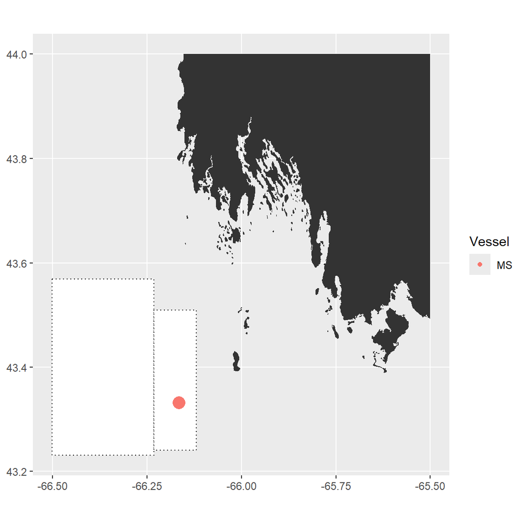

The transect with the greatest average biomass density (kg/m2) was recorded by **MS**, at the following location:

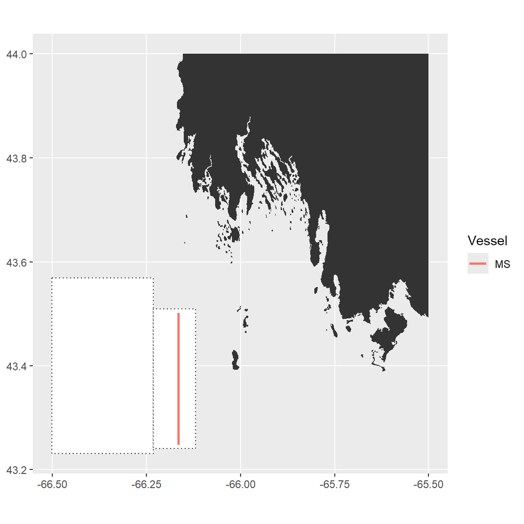

### Annual Summaries

This table does not include the biomass from adhoc surveys.

Table 4: Annual Comparison Table

| Ground | Survey Number | Current Year Survey Date | Current Year HSC Estimate | Current Year HSC Turnover Adjusted | Previous Year Survey Date | Previous Year HSC Estimate | Previous Year HSC Turnover Adjusted | Previous Year DFO Estimate | Previous Year DFO Turnover Adjusted |
| --- | --- | --- | --- | --- | --- | --- | --- | --- | --- |
| German Bank | 1 | 2025-08-04 | 6,193.766 | 6,193.766 | 2024-08-04 | 12,233 | 12,233 | 5,026 | 5,026 |
| Seal Island | 1 | 2025-08-04 | 1,159.863 | NA | 2024-08-04 | 45,930 | 45,930 | 31,328 | 31,328 |
| German Bank | 2 | 2025-08-18 | 35,008.206 | 32,591.544 | 2024-08-18 | 14,054 | 11,668 | 11,333 | 10,353 |
| Seal Island | 2 | 2025-08-18 | 6,220.048 | NA | 2024-08-18 | 6,285 | 6,285 | 5,241 | 5,241 |
| German Bank | 3 | 2025-08-31 | 30,891.606 | 21,986.028 | 2024-09-02 | 15,499 | 12,639 | 11,070 | 8,899 |
| Seal Island | 3 | 2025-08-31 | 6,499.738 | NA | 2024-09-02 | 3,770 | 3,770 | 2,914 | 2,914 |
| German Bank | 4 | 2025-09-14 | 15,323.412 | 7,753.000 | 2024-09-15 | 24,824 | 21,033 | 21,117 | 18,363 |
| Seal Island | 4 | 2025-09-14 | 18,112.492 | NA | 2024-09-15 | 1,369 | 1,369 | 1,538 | 1,538 |
| German Bank | 5 | 2025-09-28 | 6,753.911 | 2,138.000 | 2024-09-29 | 10,595 | 5,068 | 11,196 | 6,588 |
| Seal Island | 5 | 2025-09-28 | 5,048.458 | NA | 2024-09-29 | 3,134 | 3,134 | 5,125 | 5,125 |
| German Bank | 6 | NA | NA | NA | 2024-10-20 | 5,151 | 4,071 | 18,989 | 17,847 |
| Seal Island | 6 | NA | NA | NA | 2024-10-20 | 2,927 | 2,927 | 3,543 | 3,543 |
| German Bank | 7 | NA | NA | NA | 2024-11-03 | 3,004 | 1,999 | 2,989 | 0 |
| Seal Island | 7 | NA | NA | NA | 2024-11-03 | 1,089 | 1,089 | 324 | 324 |

Table 5: Annual Summary Table

| Year | Ground | HSC Estimate | HSC Turnover Adjusted | DFO Estimate | DFO Turnover Adjusted |
| --- | --- | --- | --- | --- | --- |
| 2024 | German Bank | 85,360.0 | 68,711.00 | 81,720 | 67,076 |
| 2024 | Seal Island | 64,504.0 | 64,504.00 | 50,013 | 50,013 |
| 2025 | German Bank | 94,170.9 | 70,662.34 | NA | NA |
| 2025 | Seal Island | 37,040.6 | NA | NA | NA |

## Vessel Performance

### Speed

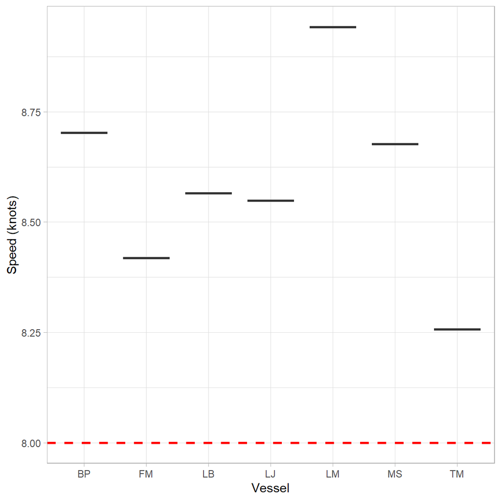

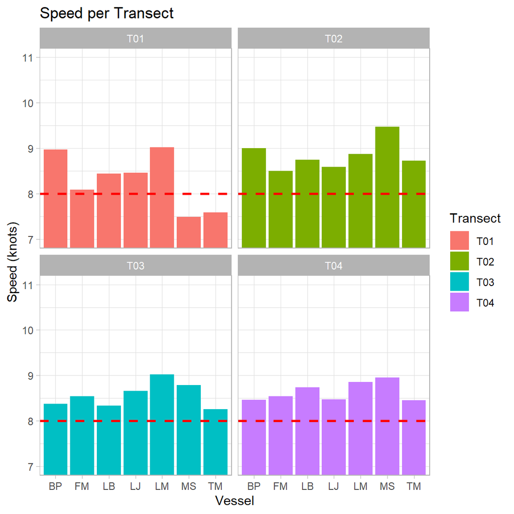

Average vessel speed was 8.59. This is above the 8 knot requirement; vessels are urged to slow down to prevent backscatter noise from interfering with the acoustic data.

The speed for each transect are rudimentary and are calculated based on distance. If a significant amount of distance is cut, the speed will appear slower.

### Distance

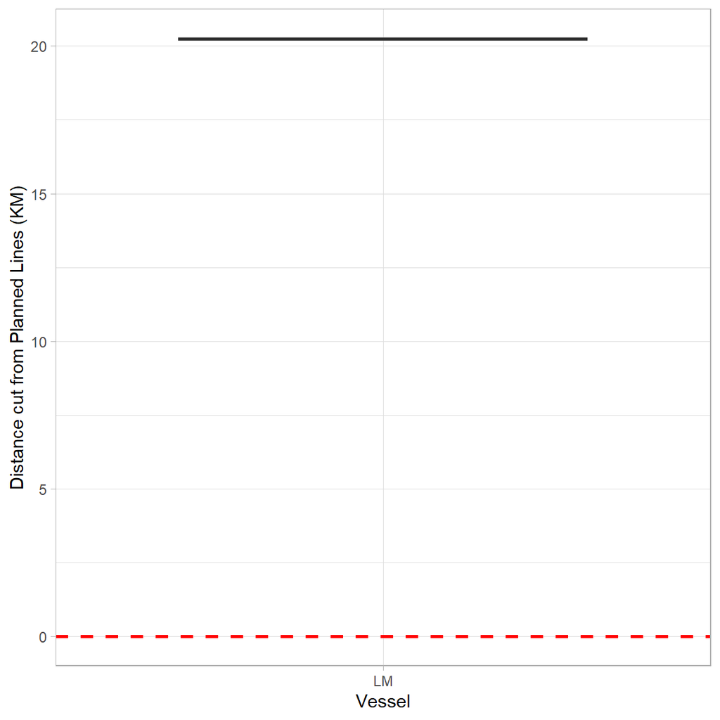

More than 2km of distance was cut from the planned lines; vessels are reminded to complete their assigned lines straight and without deviating or cutting corners short.